# Megan Robertson Coding Exercise

#First, let’s load our data package: “dslabs”. Use the function library.

```r
library(dslabs)
```

#Next, we’ll examine what the gapminder dataset is about, using the help() function.

```r
help("gapminder")
```

#According the Help window, Gapminder is a dataset with health and income outcomes for 184 countries from 1960 to 2016.

#Next, let’s look at the data itself. Using Str and Summary functions will provide a general overview.

```r
str(gapminder)
```

```
'data.frame':   10545 obs. of  9 variables:
 $ country         : Factor w/ 185 levels "Albania","Algeria",..: 1 2 3 4 5 6 7 8 9 10 ...
 $ year            : int  1960 1960 1960 1960 1960 1960 1960 1960 1960 1960 ...
 $ infant_mortality: num  115.4 148.2 208 NA 59.9 ...
 $ life_expectancy : num  62.9 47.5 36 63 65.4 ...
 $ fertility       : num  6.19 7.65 7.32 4.43 3.11 4.55 4.82 3.45 2.7 5.57 ...
 $ population      : num  1636054 11124892 5270844 54681 20619075 ...
 $ gdp             : num  NA 1.38e+10 NA NA 1.08e+11 ...
 $ continent       : Factor w/ 5 levels "Africa","Americas",..: 4 1 1 2 2 3 2 5 4 3 ...
 $ region          : Factor w/ 22 levels "Australia and New Zealand",..: 19 11 10 2 15 21 2 1 22 21 ...
```

```r
summary(gapminder)
```

[output not shown]

```r
class(gapminder)
```

```
[1] "data.frame"
```

#Now let’s only look at data from Africa. To do this, because gapminder is a dataframe, we can conditionally index the row “contient” to only have “Africa”. Once again, let’s look at str and summary of this new dataset.

```r
africandata <- gapminder[gapminder$continent == "Africa", ]
str(africandata)
```

```
'data.frame':   2907 obs. of  9 variables:
 $ country         : Factor w/ 185 levels "Albania","Algeria",..: 2 3 18 22 26 27 29 31 32 33 ...
 $ year            : int  1960 1960 1960 1960 1960 1960 1960 1960 1960 1960 ...
 $ infant_mortality: num  148 208 187 116 161 ...
 $ life_expectancy : num  47.5 36 38.3 50.3 35.2 ...
 $ fertility       : num  7.65 7.32 6.28 6.62 6.29 6.95 5.65 6.89 5.84 6.25 ...
 $ population      : num  11124892 5270844 2431620 524029 4829291 ...
 $ gdp             : num  1.38e+10 NA 6.22e+08 1.24e+08 5.97e+08 ...
 $ continent       : Factor w/ 5 levels "Africa","Americas",..: 1 1 1 1 1 1 1 1 1 1 ...
 $ region          : Factor w/ 22 levels "Australia and New Zealand",..: 11 10 20 17 20 5 10 20 10 10 ...
```

```r
summary(africandata)
```

```
         country          year      infant_mortality life_expectancy   fertility
 Algeria     :  57   Min.   :1960   Min.   : 11.40   Min.   :13.20   Min.   :1.500
 Angola      :  57   1st Qu.:1974   1st Qu.: 62.20   1st Qu.:48.23   1st Qu.:5.160
 Benin       :  57   Median :1988   Median : 93.40   Median :53.98   Median :6.160
 Botswana    :  57   Mean   :1988   Mean   : 95.12   Mean   :54.38   Mean   :5.851
 Burkina Faso:  57   3rd Qu.:2002   3rd Qu.:124.70   3rd Qu.:60.10   3rd Qu.:6.860
 Burundi     :  57   Max.   :2016   Max.   :237.40   Max.   :77.60   Max.   :8.450
 (Other)     :2565                  NA's   :226                      NA's   :51
   population             gdp               continent                          region
 Min.   :    41538   Min.   :4.659e+07   Africa  :2907   Eastern Africa           :912
 1st Qu.:  1605232   1st Qu.:8.373e+08   Americas:   0   Western Africa           :912
 Median :  5570982   Median :2.448e+09   Asia    :   0   Middle Africa            :456
 Mean   : 12235961   Mean   :9.346e+09   Europe  :   0   Northern Africa          :342
 3rd Qu.: 13888152   3rd Qu.:6.552e+09   Oceania :   0   Southern Africa          :285
 Max.   :182201962   Max.   :1.935e+11                   Australia and New Zealand:  0
 NA's   :51          NA's   :637                         (Other)                  :  0
```

#2907 observations are associated with Africa. To check our work, looking back at the above Gapminder dataframe, observations 2 and 3 are indeed African countries.

#Let’s look at different health outcomes in these countries. First we will create new variables from africandata with infant mortality and life expectancy using indexing again. We select only the relevant rows from africandata to put into a object. Finally we create a new data frame called “africaninfantlife” with the two new variables.

```r
infantmort <- africandata$infant_mortality
lifeexp <- africandata$life_expectancy
africaninfantlife <- data.frame("infant mortality" = infantmort, "life expectancy" = lifeexp)
str(africaninfantlife)
```

```
'data.frame':   2907 obs. of  2 variables:
 $ infant.mortality: num  148 208 187 116 161 ...
 $ life.expectancy : num  47.5 36 38.3 50.3 35.2 ...
```

```r
summary(africaninfantlife)
```

```
 infant.mortality life.expectancy
 Min.   : 11.40   Min.   :13.20
 1st Qu.: 62.20   1st Qu.:48.23
 Median : 93.40   Median :53.98
 Mean   : 95.12   Mean   :54.38
 3rd Qu.:124.70   3rd Qu.:60.10
 Max.   :237.40   Max.   :77.60
 NA's   :226
```

#A data frame has been created with 2907 observations with the 2 variables of infant mortality and life expectancy.

#Now the same thing for population and life expectancy.

```r
pop <- africandata$population
lifeexp <- africandata$life_expectancy
africanpoplife <- data.frame("population" = pop, "life expectancy" = lifeexp)
str(africanpoplife)
```

```
'data.frame':   2907 obs. of  2 variables:
 $ population     : num  11124892 5270844 2431620 524029 4829291 ...
 $ life.expectancy: num  47.5 36 38.3 50.3 35.2 ...
```

```r
summary(africanpoplife)
```

```
   population        life.expectancy
 Min.   :    41538   Min.   :13.20
 1st Qu.:  1605232   1st Qu.:48.23
 Median :  5570982   Median :53.98
 Mean   : 12235961   Mean   :54.38
 3rd Qu.: 13888152   3rd Qu.:60.10
 Max.   :182201962   Max.   :77.60
 NA's   :51
```

#Again another data frame has been created with 2907 observations and the 2 variables of population and life expectany.

#Let’s plot! We’ll use the basic plot function (use xlab/ylab to label our x/y axis, main to title our plot, and change the output to points using type) to look at infant mortality vs life expectancy.

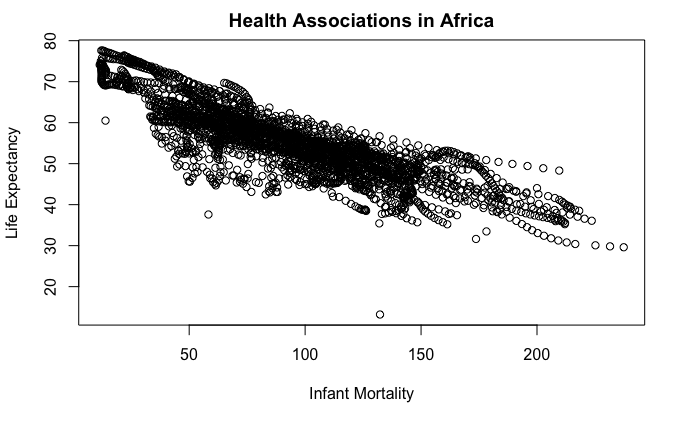

```r
plot(africaninfantlife, xlab = "Infant Mortality", ylab = "Life Expectancy", main = "Health Associations in Africa", type = "p")
```

#From this plot, you can see a negative correlation between infant mortality and life expectancy.

#Let’s look at population vs life expectancy. To improve the readability, the x-axis is converted to a log 10 scale to improve readability.

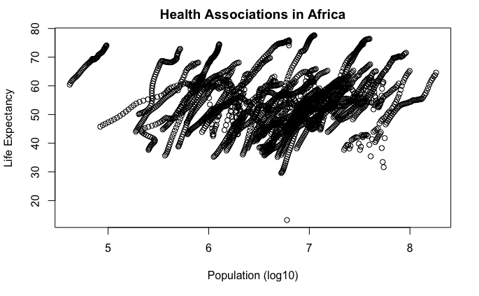

```r
plot(log10(pop), lifeexp, xlab = "Population (log10)", ylab = "Life Expectancy", main = "Health Associations in Africa", type = "p")
```

#There is a positive correlation between population size and life expectancy, which can be expected. #In both plots there are data “streaks”, which correspond to a country’s progression through the years observed.

#Instead of all the years, we will look at the year with the most data. First we need to find what years have missing data for infant mortality. To do this, let’s use is.na and which observations are missing in infant mortality.

```r
missing <- which(is.na(infantmort))
print(missing)
```

```
  [1]    8   10   15   17   18   20   23   24   37   43   53   59   61   62   63   66   68
 [18]   69   70   71   75   80   86   87   88   89   94  104  110  112  113  114  117  119
 [35]  120  121  122  126  131  137  138  139  145  155  161  163  164  165  168  170  171
 [52]  172  173  177  182  188  189  190  196  206  212  214  215  216  219  221  222  223
 [69]  224  228  233  240  241  247  257  263  265  266  267  270  272  273  274  275  279
 [86]  291  292  298  308  314  316  317  318  321  323  324  326  330  342  343  349  359
[103]  365  367  368  369  372  374  375  377  381  400  410  416  418  419  420  423  425
[120]  426  428  432  451  461  470  474  476  479  483  502  525  527  530  534  553  563
[137]  576  578  581  585  604  614  627  629  632  636  655  665  678  680  683  687  706
[154]  716  729  731  734  738  767  780  782  785  789  818  833  836  869  884  887  920
[171]  935  971  986 1037 1088 2857 2858 2859 2860 2861 2862 2863 2864 2865 2866 2867 2868
[188] 2869 2870 2871 2872 2873 2874 2875 2876 2877 2878 2879 2880 2881 2882 2883 2884 2885
[205] 2886 2887 2888 2889 2890 2891 2892 2893 2894 2895 2896 2897 2898 2899 2900 2901 2902
[222] 2903 2904 2905 2906 2907
```

#There are 226 observations with missing data in infant mortality for our African dataset. Let’s convert these to year data to see what years are missing.

```r
yeardata <- gapminder$year[missing]
print(yeardata)
```

```
  [1] 1960 1960 1960 1960 1960 1960 1960 1960 1960 1960 1960 1960 1960 1960 1960 1960 1960
 [18] 1960 1960 1960 1960 1960 1960 1960 1960 1960 1960 1960 1960 1960 1960 1960 1960 1960
 [35] 1960 1960 1960 1960 1960 1960 1960 1960 1960 1960 1960 1960 1960 1960 1960 1960 1960
 [52] 1960 1960 1960 1960 1961 1961 1961 1961 1961 1961 1961 1961 1961 1961 1961 1961 1961
 [69] 1961 1961 1961 1961 1961 1961 1961 1961 1961 1961 1961 1961 1961 1961 1961 1961 1961
 [86] 1961 1961 1961 1961 1961 1961 1961 1961 1961 1961 1961 1961 1961 1961 1961 1961 1961
[103] 1961 1961 1961 1961 1962 1962 1962 1962 1962 1962 1962 1962 1962 1962 1962 1962 1962
[120] 1962 1962 1962 1962 1962 1962 1962 1962 1962 1962 1962 1962 1962 1962 1962 1962 1963
[137] 1963 1963 1963 1963 1963 1963 1963 1963 1963 1963 1963 1963 1963 1963 1963 1963 1963
[154] 1963 1963 1963 1963 1963 1964 1964 1964 1964 1964 1964 1964 1964 1964 1964 1964 1964
[171] 1965 1965 1965 1965 1965 1975 1975 1975 1975 1975 1975 1975 1975 1975 1975 1975 1975
[188] 1975 1975 1975 1975 1975 1975 1975 1975 1975 1975 1975 1975 1975 1975 1975 1975 1975
[205] 1975 1975 1975 1975 1975 1975 1975 1975 1975 1975 1975 1975 1975 1975 1975 1975 1975
[222] 1975 1975 1975 1975 1975
```

#We will look at year 2000 data. Let’s create another datas frame with just year 2000 data selected from our africandata.

```r
yeary2k <- africandata[africandata$year == 2000, ]
str(yeary2k)
```

```
'data.frame':   51 obs. of  9 variables:
 $ country         : Factor w/ 185 levels "Albania","Algeria",..: 2 3 18 22 26 27 29 31 32 33 ...
 $ year            : int  2000 2000 2000 2000 2000 2000 2000 2000 2000 2000 ...
 $ infant_mortality: num  33.9 128.3 89.3 52.4 96.2 ...
 $ life_expectancy : num  73.3 52.3 57.2 47.6 52.6 46.7 54.3 68.4 45.3 51.5 ...
 $ fertility       : num  2.51 6.84 5.98 3.41 6.59 7.06 5.62 3.7 5.45 7.35 ...
 $ population      : num  31183658 15058638 6949366 1736579 11607944 ...
 $ gdp             : num  5.48e+10 9.13e+09 2.25e+09 5.63e+09 2.61e+09 ...
 $ continent       : Factor w/ 5 levels "Africa","Americas",..: 1 1 1 1 1 1 1 1 1 1 ...
 $ region          : Factor w/ 22 levels "Australia and New Zealand",..: 11 10 20 17 20 5 10 20 10 10 ...
```

```r
summary(yeary2k)
```

```
         country        year      infant_mortality life_expectancy   fertility
 Algeria     : 1   Min.   :2000   Min.   : 12.30   Min.   :37.60   Min.   :1.990
 Angola      : 1   1st Qu.:2000   1st Qu.: 60.80   1st Qu.:51.75   1st Qu.:4.150
 Benin       : 1   Median :2000   Median : 80.30   Median :54.30   Median :5.550
 Botswana    : 1   Mean   :2000   Mean   : 78.93   Mean   :56.36   Mean   :5.156
 Burkina Faso: 1   3rd Qu.:2000   3rd Qu.:103.30   3rd Qu.:60.00   3rd Qu.:5.960
 Burundi     : 1   Max.   :2000   Max.   :143.30   Max.   :75.00   Max.   :7.730
 (Other)     :45
   population             gdp               continent                        region
 Min.   :    81154   Min.   :2.019e+08   Africa  :51   Eastern Africa           :16
 1st Qu.:  2304687   1st Qu.:1.274e+09   Americas: 0   Western Africa           :16
 Median :  8799165   Median :3.238e+09   Asia    : 0   Middle Africa            : 8
 Mean   : 15659800   Mean   :1.155e+10   Europe  : 0   Northern Africa          : 6
 3rd Qu.: 17391242   3rd Qu.:8.654e+09   Oceania : 0   Southern Africa          : 5
 Max.   :122876723   Max.   :1.329e+11                 Australia and New Zealand: 0
                                                       (Other)                  : 0
```

#Ok we have 51 observations with 9 variables!

#Let’s plot! We don’t need to do intermediate variables, we can just select what variables we want out of our new year2k data frame. Again, let’s label the axes and title

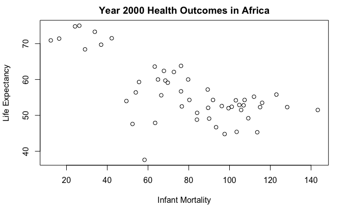

```r
plot(yeary2k$infant_mortality, yeary2k$life_expectancy, xlab = "Infant Mortality", ylab = "Life Expectancy", main = "Year 2000 Health Outcomes in Africa", type = "p")
```

#There is still a negative correlation between infant mortality and life expectancy.

#Let’s look at population and life expectancy. Again, population is converted into log10.

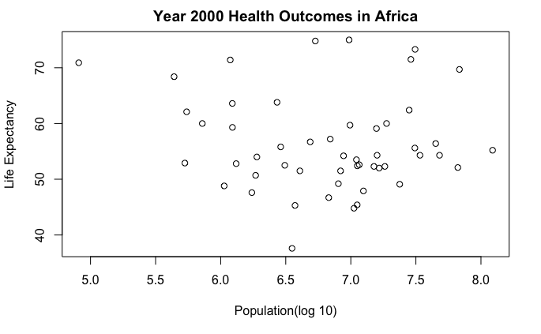

```r
plot(log10(yeary2k$population), yeary2k$life_expectancy, xlab = "Population(log 10)", ylab = "Life Expectancy", main = "Year 2000 Health Outcomes in Africa", type = "p")
```

#It appears there is no correlation between population and life expectancy. Let’s run some statistics! We will use the lm function which is used to fit linear models. Infant mortality and population are the predictors and life expectancy is the outcome.

```r
fit1 <- lm(yeary2k$life_expectancy ~ yeary2k$infant_mortality)
fit2 <- lm(yeary2k$life_expectancy ~ yeary2k$population)
```

#Let’s run a summary on these linear models.

```r
summary(fit1)
```

```
Call:
lm(formula = yeary2k$life_expectancy ~ yeary2k$infant_mortality)

Residuals:
     Min       1Q   Median       3Q      Max
-22.6651  -3.7087   0.9914   4.0408   8.6817

Coefficients:
                         Estimate Std. Error t value Pr(>|t|)
(Intercept)              71.29331    2.42611  29.386  < 2e-16 ***
yeary2k$infant_mortality -0.18916    0.02869  -6.594 2.83e-08 ***
---
Signif. codes:  0 ‘***’ 0.001 ‘**’ 0.01 ‘*’ 0.05 ‘.’ 0.1 ‘ ’ 1

Residual standard error: 6.221 on 49 degrees of freedom
Multiple R-squared:  0.4701,    Adjusted R-squared:  0.4593
F-statistic: 43.48 on 1 and 49 DF,  p-value: 2.826e-08
```

```r
summary(fit2)
```

```
Call:
lm(formula = yeary2k$life_expectancy ~ yeary2k$population)

Residuals:
    Min      1Q  Median      3Q     Max
-18.429  -4.602  -2.568   3.800  18.802

Coefficients:
                    Estimate Std. Error t value Pr(>|t|)
(Intercept)        5.593e+01  1.468e+00  38.097   <2e-16 ***
yeary2k$population 2.756e-08  5.459e-08   0.505    0.616
---
Signif. codes:  0 ‘***’ 0.001 ‘**’ 0.01 ‘*’ 0.05 ‘.’ 0.1 ‘ ’ 1

Residual standard error: 8.524 on 49 degrees of freedom
Multiple R-squared:  0.005176,  Adjusted R-squared:  -0.01513
F-statistic: 0.2549 on 1 and 49 DF,  p-value: 0.6159
```

#The p-value of Fit1 is 2.826e-08. This means that the correlation between higher infant mortality seems to be associated with lower life expectancy, which makes sense as shown on the plot.

#The p-value of Fit2 is 0.6159. There is in line with the graph as there seems to be no correlation between population size and life expectancy.

#However, we are just looking at one year so population size changes are lost in this dataset, compared to the previous data of all years.